# Learning about Fourier Curves

*A description of how fourier curves work and an exploration into how these* *can be used to fit curves to pharmacokinetic absorption data.* *For more information check out these links:*

https://onlinelibrary.wiley.com/doi/pdf/10.1002/9781118593233.ch12

http://www.di.fc.ul.pt/~jpn/r/fourier/fourier.html

# ——————————————————————————–

### Simple Sinusoidal Waves

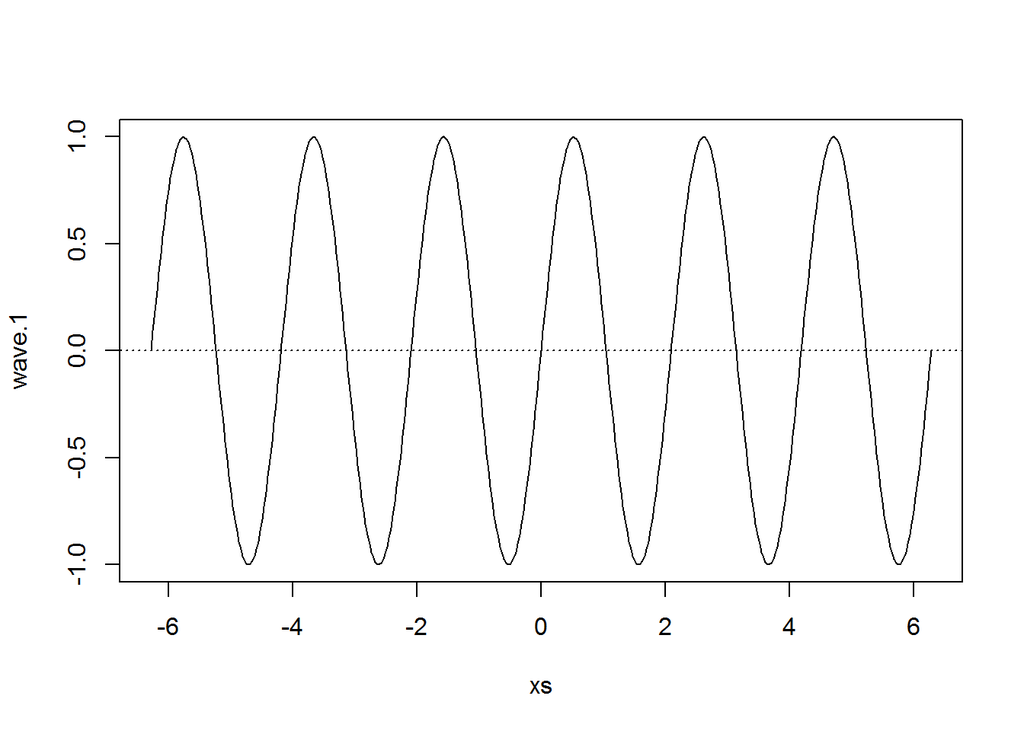

```r
  xs <- seq(-2*pi, 2*pi, pi/100)
  wave.1 <- sin(3*xs)
  wave.2 <- sin(10*xs)
  plot(xs,wave.1, type = "l", ylim = c(-1, 1))
  abline(h = 0,lty = 3)
```

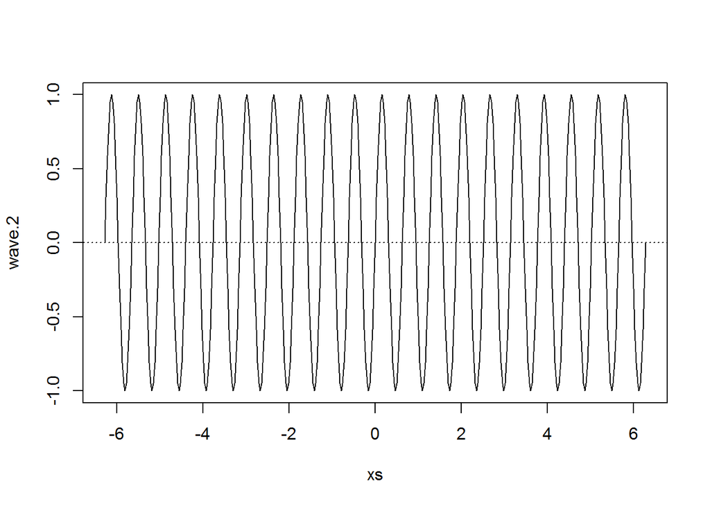

```r
  plot(xs,wave.2, type = "l", ylim = c(-1, 1))
  abline(h = 0, lty = 3)
```

Here we have two sine waves. Sine wave notation is below:
$$y(t) = Asin(2\pi ft+\phi) = Asin(\omega t+\phi)$$
where:

- $A$ is the amplitude (peak deviation from zero)
- $f$ is the frequency, the number of oscillations that occur each unit of time
- $\omega$ is angular frequency, rate of change of the function in units of radians per unit of time
- $\phi$ is the phase, specifies in radians where in the cycle the oscillation is at $t = 0$

It should be noted that a phase shifted sine wave can also be represented as seen below:
$$sin(a+b)=sin(a)cos(b)+cos(a)sin(b)$$

### Fourier Series using Sine Waves

Joseph Fourier showed that any periodic wave can be represented by a sum of simple sine waves. This sum is called the **Fourier Series**.

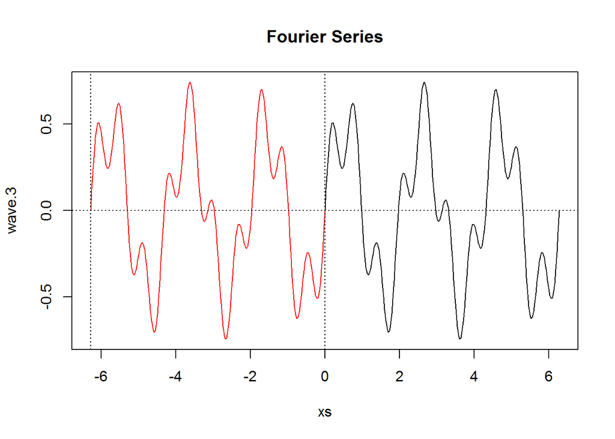

```r
  wave.3 <- 0.5 * wave.1 + 0.25 * wave.2
  plot(xs, wave.3, type = "l")
  title("Fourier Series")
  abline(h = 0,lty = 3)
  repeat.xs <- seq(-2*pi, 0, pi/100)
  wave.3.repeat <- 0.5*sin(3*repeat.xs) + 0.25*sin(10*repeat.xs)
  points(repeat.xs, wave.3.repeat, type = "l",col = "red")
  abline(h = 0,v = c(-2*pi, 0), lty = 3)
```

A Fourier Series is periodic, repeating according to it’s frequency $f$ and wavelength $\lambda$. Non-periodic waves do not have a frequency or wavelength. What occurs within a single period is more interesting for pharmacokinetics.

Some important things are:

- The **fundamental period**, $T$, is the period of time that the samples were taken in. For the case of an oral drug this could be 24 hours. If it is multi-dose data then the fundamental period is 24 multiplied by the number of sequential doses.
- The **sampling rate**, $sr$ is the number of samples taken over a time period. The interval between these times is called the **sample interval**, $si$, which is the fundamental period time divided by the number of samples $N$. Therefore $si = \frac{T}{N}$.
- The **fundamental frequency**, $f_0$, which is $\frac{1}{T}$. The fundamental frequency of the repeating pattern, or how long the wavelength is. In the waves above, the fundamental frequency was $\frac{1}{2\pi}$. The frequencies of the wave components must be integer multiples of the fundamental frequency.
- The **angular frequency**, mentioned in the description of a sine wave is determined from these values like so, $\omega=2\pi f_0$

The Fourier Series above is represented as:
$$f(t)=0.5sin(3\omega t)+0.25sin(10\omega t)$$

It should be noted that the frequency $f$ of the simple waves, is separate from the fundamental frequency $f_0$ of the complex wave, which is used to determine the angular frequency $\omega$.

So if we were to implement this as a function in R:

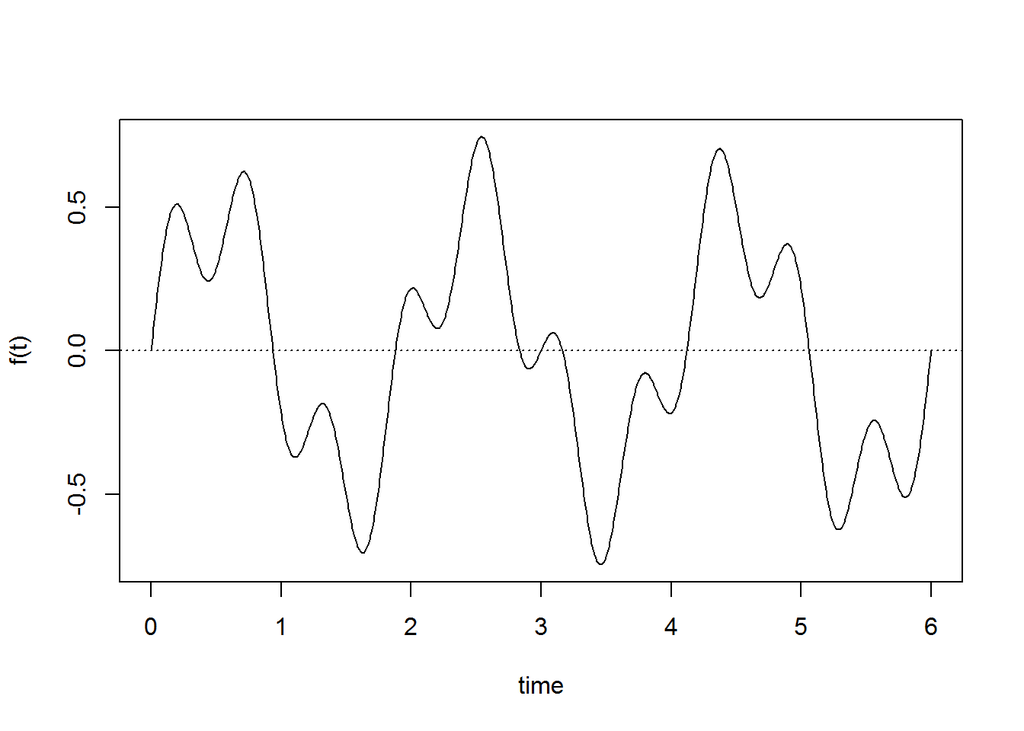

```r
# Set up data parameters
  acq.f <- 100  # data aquisition frequency
  t.int <- 6  # measuring time interval
  t <- seq(0, t.int, 1/acq.f)  # vector of sampling times
  f.0 <- 1/t.int  # fundamental frequency
  w <- 2*pi*f.0  # angular frequency

# Set up wave parameters
  in.freq <- c(3, 10)  # frequency of sine waves
  in.phase <- c(0, 0)  # phase (delay of sine waves)
  in.amp <- c(0.5, 0.25)  # amplitude (strength of sine waves)

# Define function
  fn <- function(t, w) {
    sum(in.amp*sin(in.freq*w*t + in.phase))
  }

# Plot using this function
  pred <- sapply(t, function(t) fn(t, w))
  plot(t, pred, type = "l", xlab = "time", ylab = "f(t)")
  abline(h = 0, lty = 3)
```

This could then be further enhanced by using a function to create our fourier function.

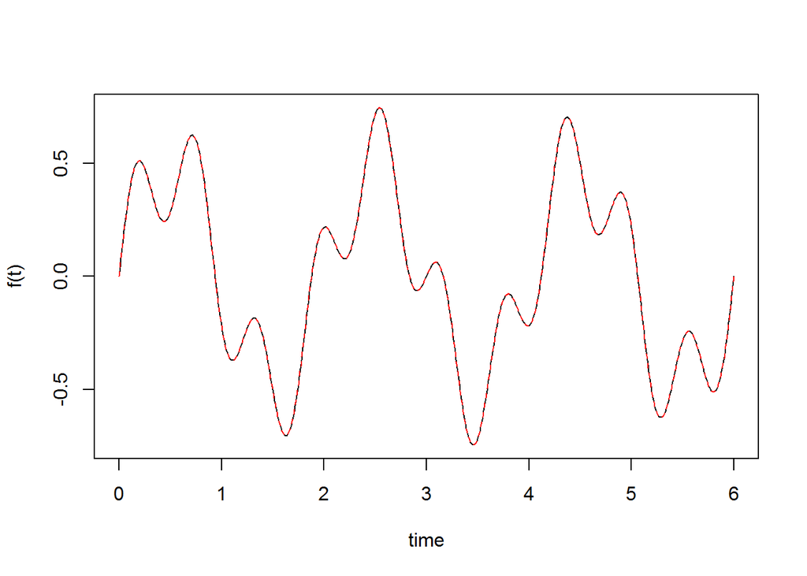

```r
# Define a function that gives a function as an output
  fourierfn <- function(freq, phase, amp) {
    function(t, w) {
      sum(amp*sin(freq*w*t + phase))
    }
  }

# Create your new fourier function and plot over the top of the previous plot
  mywave <- fourierfn(in.freq, in.phase, in.amp)
  pred <- sapply(t, function(t) fn(t, w))
  plot(t, pred, type = "l", xlab = "time", ylab = "f(t)")
  pred <- sapply(t, function(t) mywave(t, w))
  lines(t, pred, type = "l", xlab = "time", ylab = "f(t)", lty = 2, col = "red")
```

### Fourier Series using Sine and Cosine Waves

While the addition of two sine waves can be used in a Fourier curve, the same goes for having both a sine and a cosine wave. But what advantages come with this?

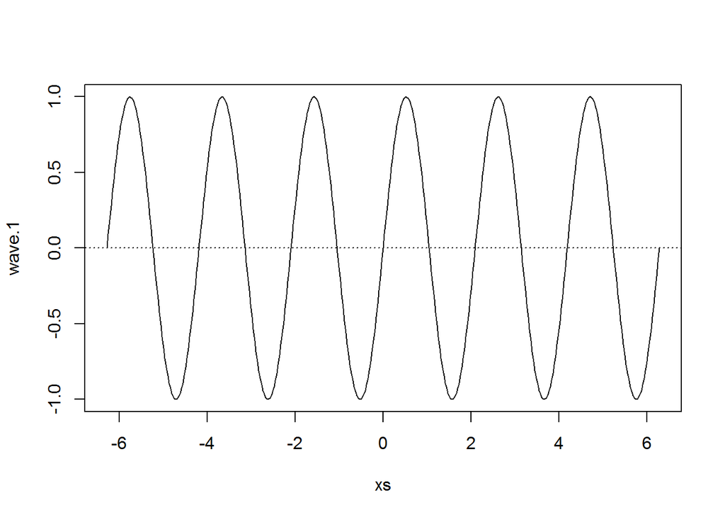

```r
  xs <- seq(-2*pi, 2*pi, pi/100)
  wave.1 <- sin(3*xs)
  wave.2 <- cos(10*xs)
  plot(xs,wave.1, type = "l", ylim = c(-1, 1))
  abline(h = 0,lty = 3)
```

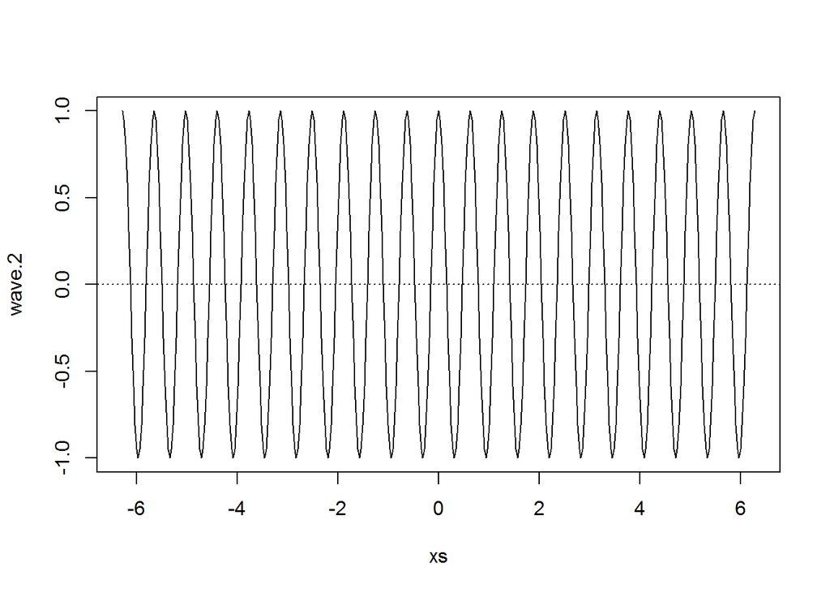

```r
  plot(xs,wave.2, type = "l", ylim = c(-1, 1))
  abline(h = 0, lty = 3)
```

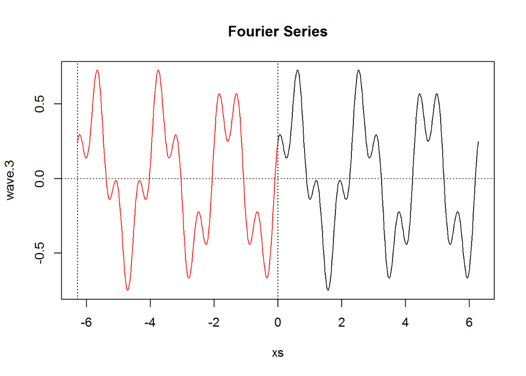

```r
  wave.3 <- 0.5 * wave.1 + 0.25 * wave.2
  plot(xs, wave.3, type = "l")
  title("Fourier Series")
  abline(h = 0,lty = 3)
  repeat.xs <- seq(-2*pi, 0, pi/100)
  wave.3.repeat <- 0.5*sin(3*repeat.xs) + 0.25*cos(10*repeat.xs)
  points(repeat.xs, wave.3.repeat, type = "l",col = "red")
  abline(h = 0,v = c(-2*pi, 0), lty = 3)
```

The equation for these functions are below:
$$h_1(f,j)=A+Bcos(\omega t)+Csin(\omega t)$$
$$h_2(f,j)=h_1(f,j)+Dcos(2\omega t)+Esin(2\omega t)$$
$$h_3(f,j)=h_2(f,j)+Dcos(4\omega t)+Esin(4\omega t), etc.$$
I think these may be beneficial as they allow for phase shifting to occur without adding additional parameters. This would make it more beneficial for curve fitting.

### Use in Pharmacokinetics

Fourier Series have more components that just this and can get quite complex, but the description above is sufficient for fitting the a Fourier curve to pharmacokinetic data.

Lets observe the following dataset:

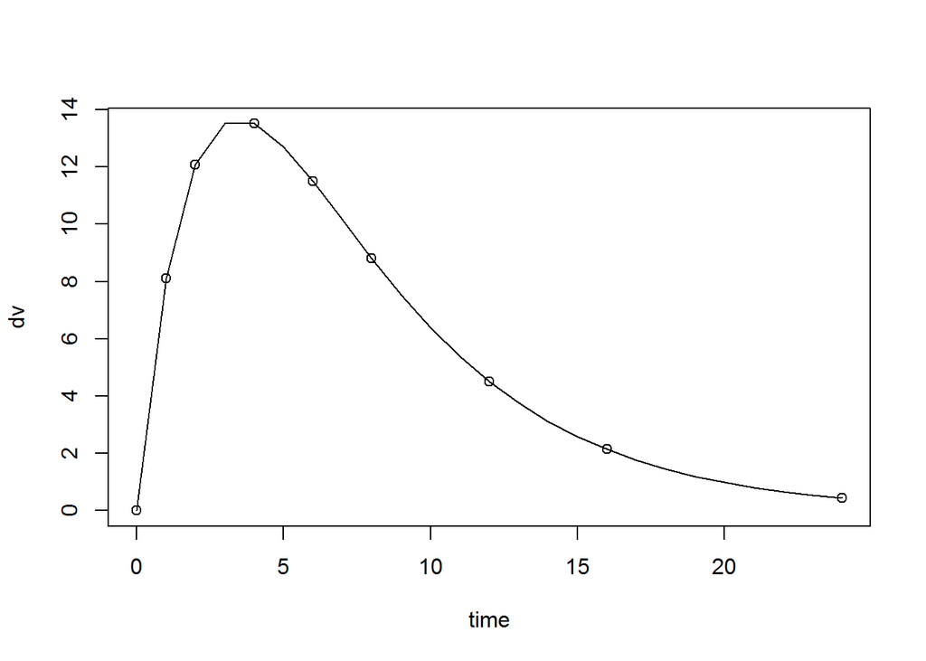

```r
  with(subdata, plot(time, dv))
  with(absdata, lines(time, sumexp))
```

This data represents a drug with one-compartment pharmacokinetics and first-order absorption. Theoretically we can fit a Fourier curve to this!

Below is some code that fits a Fourier series to data

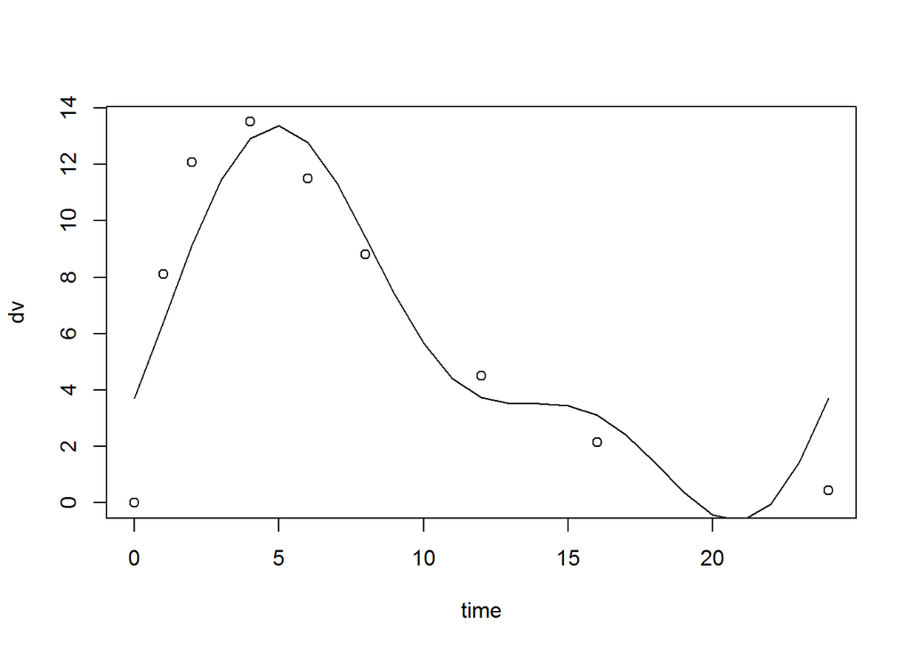

```r
  y <- absdata$sumexp
  pr <- 2 # number of pairs
  n <- length(y) # sample size
  tmp <- rep(NA, 2*pr*n) #construction of a vector to be reshaped to a matrix
  col_p <- matrix(tmp, n, 2*pr) #reshape the vector tmp to a matrix with
  # n rows and 2*pr columns
  for(k in 1:pr) { # create pr columns of cosines followed by
    # pr columns of sines
    for(j in 1:n) {
      col_p[j,k] <- cos(2*pi*j*k/24)
      col_p[j, pr+k] <- sin(2*pi*j*k/24)
    }
  }
  ones <- rep(1,n)
  X <- cbind(ones,col_p)
  fit <- lm(y ~ 0 + X)
  with(subdata, plot(time, dv))
  lines(0:24, X%*%fit[[1]])
```

```r
  sum(fit$resid^2) # print out SSE for the current model
```

```
## [1] 54.74508
```

For a fitted curve with only 1 pair the coefficients that result from `lm()` are $A$ , $B$ and $C$ from the equation on Fourier Series for Sine and Cosine waves.

We want to find the number of pairs that provides the best fit. For this we need to make a few functions and then use them with `optim()`.